# Deep Hit (part 2)

```
📍 Working Locally at: C:\Users\andre\DH_Analysis
📂 Output Images will be saved to: C:\Users\andre\DH_Analysis\dh6_plots

✅ Found local copy of data: C:\Users\andre\DH_Analysis\temp_shap_data.pkl

🎨 Generating plots for: death @ 3 Months
```

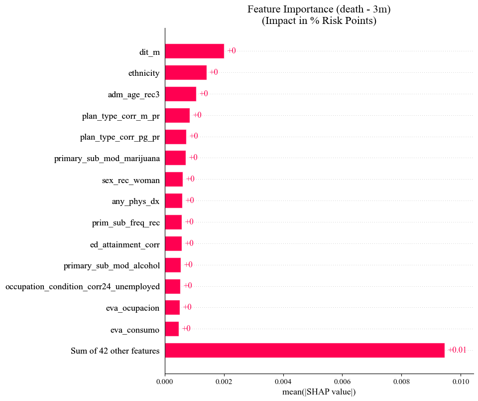

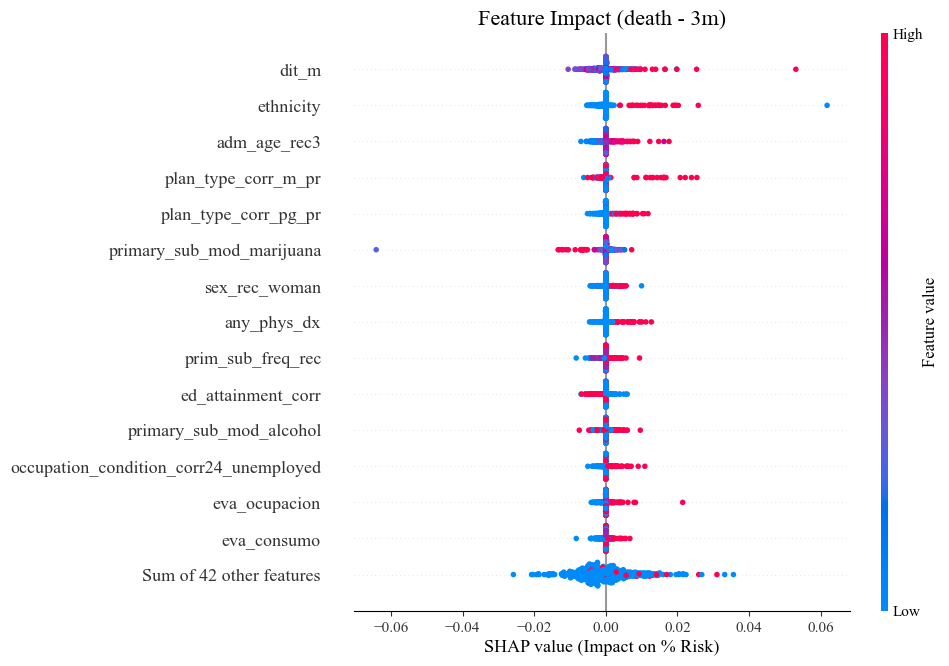

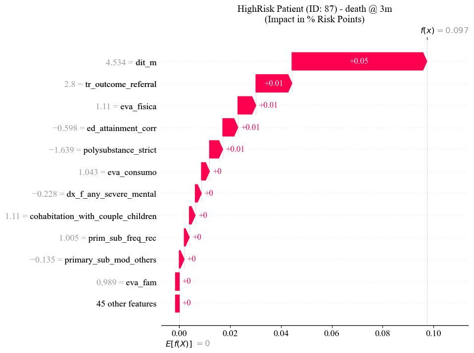

```
   ✅ Saved: HighRisk (ID: 87)
```

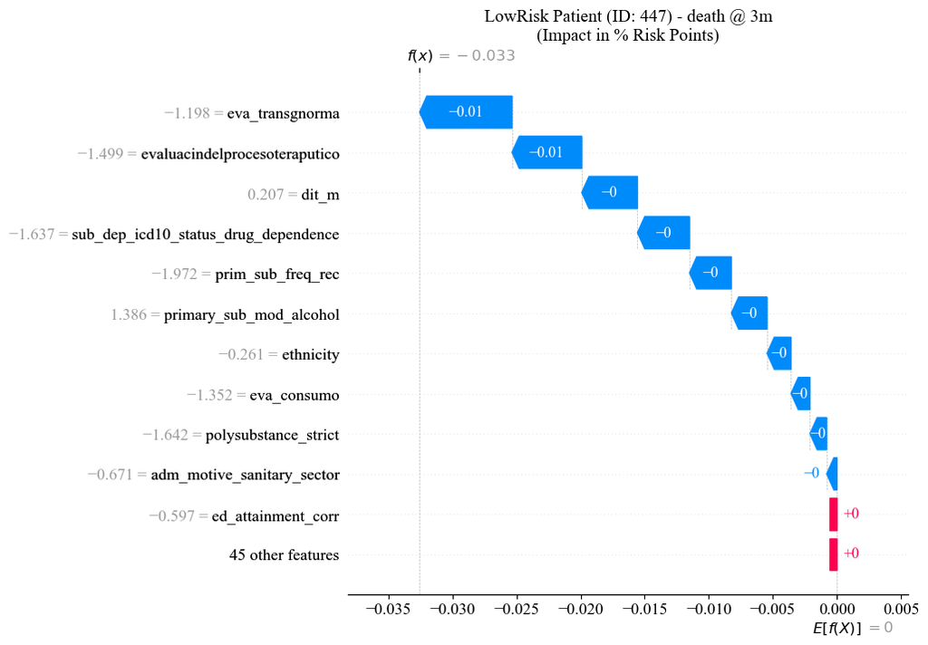

```
   ✅ Saved: LowRisk (ID: 447)

🎨 Generating plots for: death @ 12 Months
```

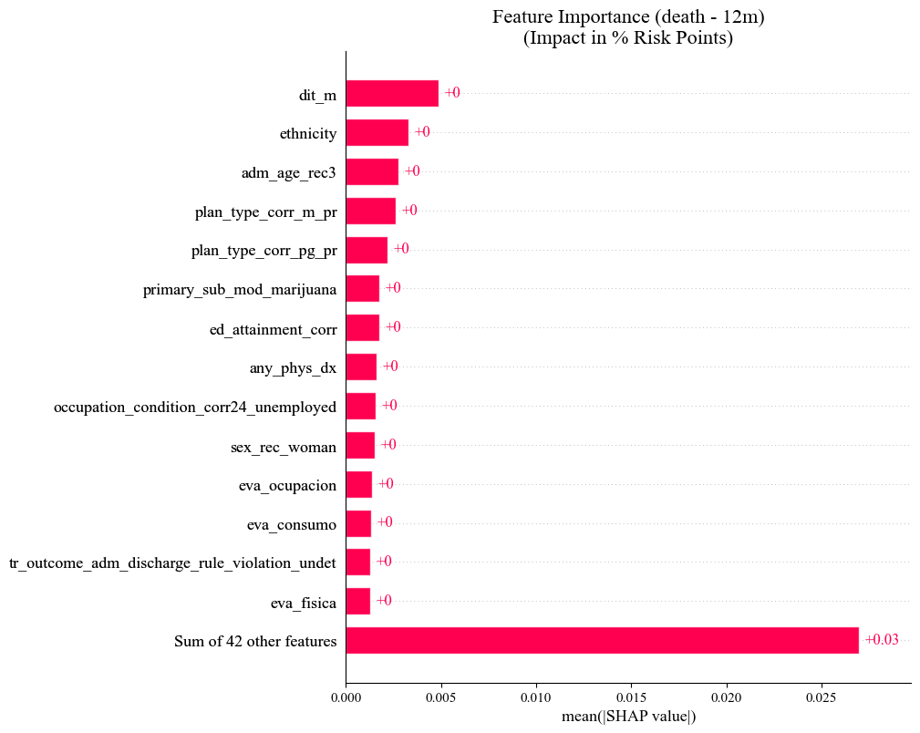

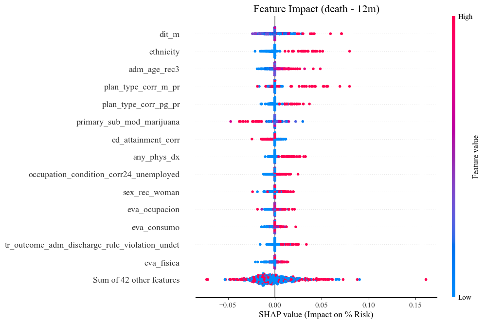

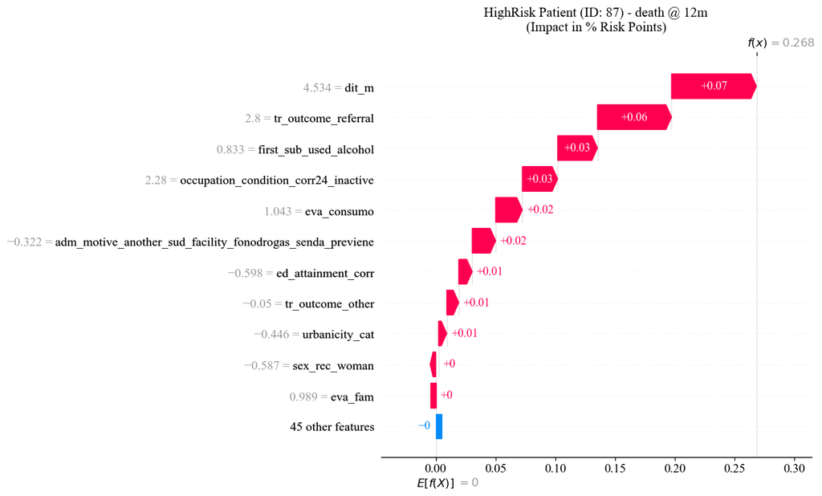

```
   ✅ Saved: HighRisk (ID: 87)
```

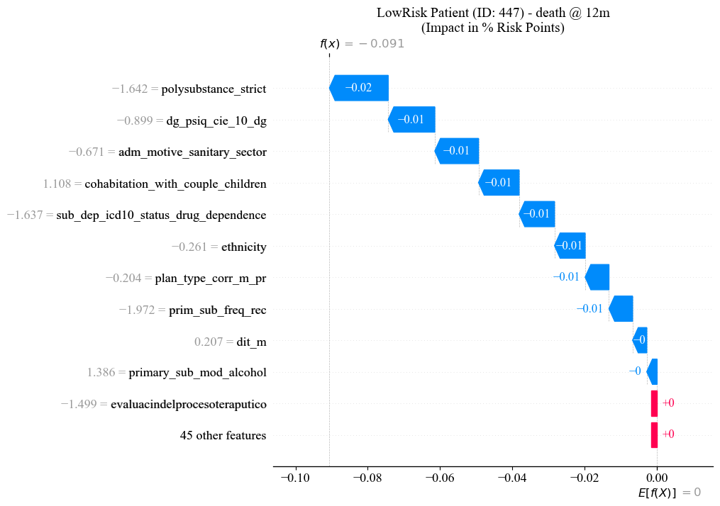

```
   ✅ Saved: LowRisk (ID: 447)

🎨 Generating plots for: death @ 24 Months
```

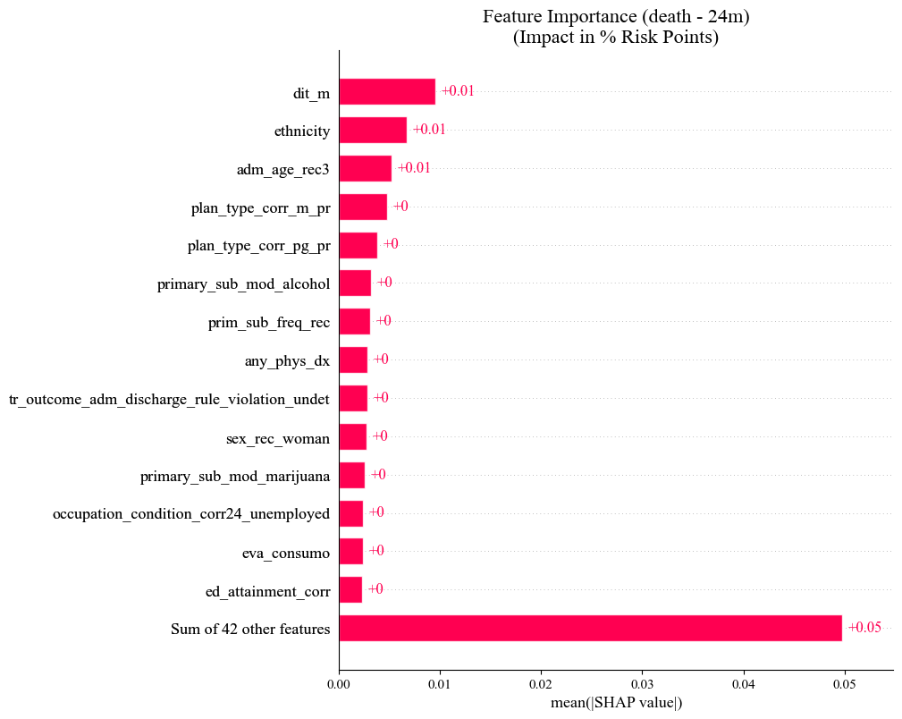

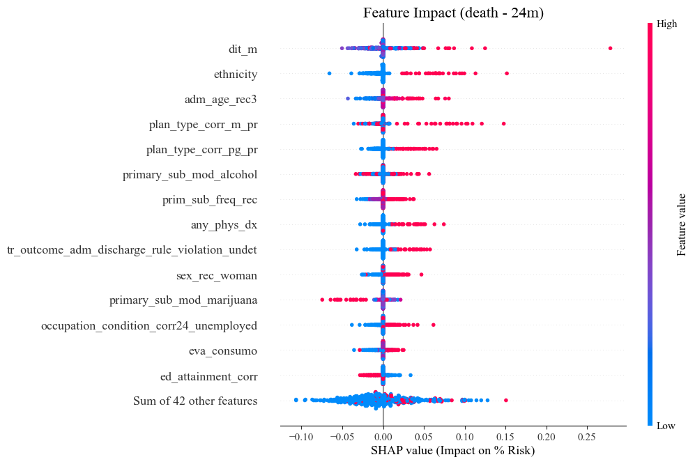

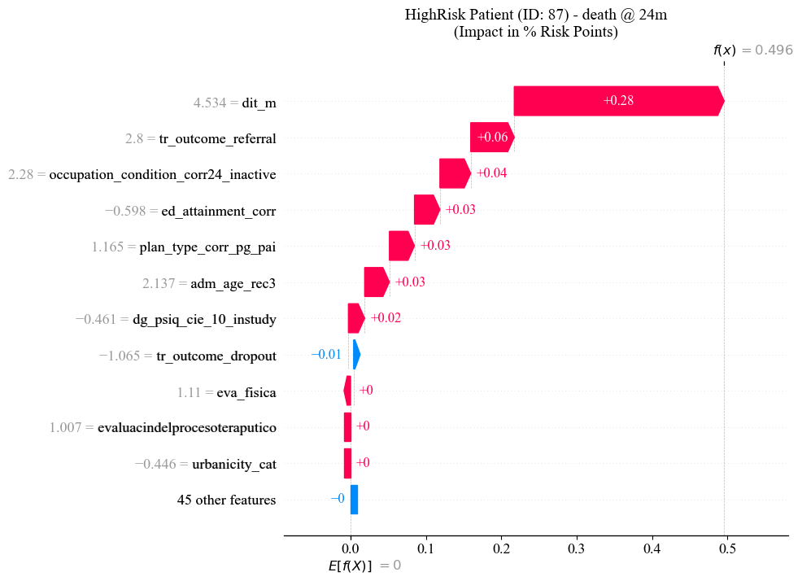

```
   ✅ Saved: HighRisk (ID: 87)
```

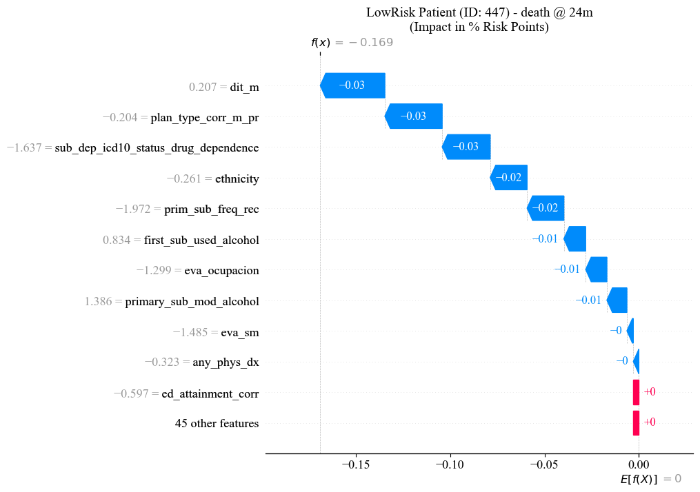

```
   ✅ Saved: LowRisk (ID: 447)

🎨 Generating plots for: death @ 48 Months
```

[36 more figures not shown]

```
   ✅ Saved: LowRisk (ID: 447)

🏁 Done! Generated plots for 12 scenarios.
📂 Open this folder to see images: C:\Users\andre\DH_Analysis\dh6_plots
📤 Uploaded images back to Google Drive folder: G:\My Drive\Alvacast\SISTRAT 2023\dh\dh6
```

```python
#@title 📊 Step 6: SHAP Plots (High/Low Risk + Percentage Scaling + Safe Path)
import pickle
import shap
import matplotlib.pyplot as plt
import pandas as pd
import numpy as np
import os
import shutil

# --- CONFIGURATION ---
# 1. Source File (Assumes script is running from G: Drive folder)
# We use os.getcwd() to find the file in the current folder
G_DRIVE_PATH = os.path.join(os.getcwd(), "DH4_Final_AJ_20260209_2329_SHAP_MultiHorizon.pkl")

# 2. Setup SAFE Local Paths (On your C: Drive)
# This creates a folder "DH_Analysis" in your User folder to bypass G: drive errors
USER_HOME = os.path.expanduser("~")
WORK_DIR = os.path.join(USER_HOME, "DH_Analysis")
os.makedirs(WORK_DIR, exist_ok=True)

# Local destination for the pickle
LOCAL_PKL = os.path.join(WORK_DIR, "temp_shap_data.pkl")

# Output folder for images
OUTPUT_DIR = os.path.join(WORK_DIR, "dh6_plots")
os.makedirs(OUTPUT_DIR, exist_ok=True)

print(f"📍 Working Locally at: {WORK_DIR}")
print(f"📂 Output Images will be saved to: {OUTPUT_DIR}")

# --- 1. RESCUE DATA (Copy from G: to C:) ---
if not os.path.exists(LOCAL_PKL):
    print(f"\n🔄 Copying file from G: Drive to local disk...")
    try:
        shutil.copyfile(G_DRIVE_PATH, LOCAL_PKL)
        print("   ✅ Copy successful!")
    except Exception as e:
        print(f"   ❌ Copy Failed: {e}")
        print("   👉 Solution: Manually copy the .pkl file to your C: drive and update the path.")
        raise
else:
    print(f"\n✅ Found local copy of data: {LOCAL_PKL}")

# Load the local copy
with open(LOCAL_PKL, 'rb') as f:
    shap_data_export = pickle.load(f)

# --- 2. PLOTTING FUNCTION ---
def generate_shap_plots(outcome_name, horizon, shap_dict):
    print(f"\n🎨 Generating plots for: {outcome_name} @ {horizon} Months")

    raw_values = shap_dict['shap_values']
    raw_data = shap_dict['data']
    feature_names = raw_data.columns.tolist()

    # 🟢 MINIMAL FIX: Scale values by 100 to show percentages
    # This turns "0.001" (which plots as +0) into "0.1" (which plots as +0.1)
    scaled_values = raw_values * 100

    # Reconstruct Object using SCALED values
    expl = shap.Explanation(
        values=scaled_values,
        data=raw_data.values,
        feature_names=feature_names,
        base_values=np.zeros(scaled_values.shape[0])
    )

    # A. BAR PLOT
    plt.figure(figsize=(10, 8))
    shap.plots.bar(expl, show=False, max_display=15)
    plt.title(f"Feature Importance ({outcome_name} - {horizon}m)\n(Impact in % Risk Points)", fontsize=16)
    plt.savefig(f"{OUTPUT_DIR}/DH6_Bar_{outcome_name}_{horizon}m.png", bbox_inches='tight', dpi=300)
    plt.savefig(f"{OUTPUT_DIR}/DH6_Bar_{outcome_name}_{horizon}m.pdf", bbox_inches="tight")
    plt.show()
    plt.close()

    # B. BEESWARM PLOT
    plt.figure(figsize=(10, 8))
    shap.plots.beeswarm(expl, show=False, max_display=15)
    plt.title(f"Feature Impact ({outcome_name} - {horizon}m)", fontsize=16)
    plt.xlabel("SHAP value (Impact on % Risk)")
    plt.savefig(f"{OUTPUT_DIR}/DH6_Beeswarm_{outcome_name}_{horizon}m.png", bbox_inches='tight', dpi=300)
    plt.savefig(f"{OUTPUT_DIR}/DH6_Beeswarm_{outcome_name}_{horizon}m.pdf", bbox_inches="tight")
    plt.show()
    plt.close()

    # C. WATERFALL PLOTS
    # Find interesting cases (High Risk vs Low Risk)
    # Calculate total risk deviation for every patient using RAW values (sorting is same)
    total_risk_dev = np.sum(raw_values, axis=1)

    # 🟢 YOUR LOGIC: Highest vs Lowest Risk
    high_risk_idx = np.argsort(total_risk_dev)[-1]  # Max deviation (Highest Risk)
    low_risk_idx  = np.argsort(total_risk_dev)[0]   # Min deviation (Lowest Risk)

    cases = [
        ('HighRisk', high_risk_idx),
        ('LowRisk',  low_risk_idx)
    ]

    for label, idx in cases:
        plt.figure(figsize=(10, 8))
        try:
            shap.plots.waterfall(expl[idx], show=False, max_display=12)

            # 🟢 TITLE: Includes Row ID and % label
            plt.title(f"{label} Patient (ID: {idx}) - {outcome_name} @ {horizon}m\n(Impact in % Risk Points)", fontsize=14)

            fname = f"{OUTPUT_DIR}/DH6_Waterfall_{outcome_name}_{horizon}m_{label}_ID{idx}"
            plt.savefig(fname + ".png", bbox_inches='tight', dpi=300)
            plt.savefig(fname + ".pdf", bbox_inches='tight')
            plt.show()
            print(f"   ✅ Saved: {label} (ID: {idx})")
        except Exception as e:
            print(f"   ⚠️ Failed: {e}")
        finally:
            plt.close()

# --- 3. EXECUTION ---
outcomes = ['death', 'readm']
count = 0

for outcome in outcomes:
    if outcome in shap_data_export:
        horizons_dict = shap_data_export[outcome]
        for horizon, data_dict in horizons_dict.items():
            if data_dict and 'shap_values' in data_dict:
                generate_shap_plots(outcome, horizon, data_dict)
                count += 1

print(f"\n🏁 Done! Generated plots for {count} scenarios.")
print(f"📂 Open this folder to see images: {OUTPUT_DIR}")

# --- 4. OPTIONAL: COPY BACK TO G: DRIVE ---
# Tries to copy images back to Google Drive (if accessible)
try:
    dest_folder = os.path.join(os.getcwd(), "dh6")
    shutil.copytree(OUTPUT_DIR, dest_folder, dirs_exist_ok=True)
    print(f"📤 Uploaded images back to Google Drive folder: {dest_folder}")
except Exception as e:
    print(f"⚠️ Could not copy back to G: drive (likely due to device error): {e}")
    print("   ✅ Your images are safe on your C: drive at the path above.")
```

### Export to excel

1. Computes per-horizon SHAP importance for every predictor and outcome
2. Classifies predictors as risk, protective, or mixed via SHAP–value correlation
3. Quantifies robustness using variability of SHAP effects across patients
4. Produces ranked, time-specific predictor tables for death and readmission
5. Exports publication-ready Excel reports with automated local + Drive saving

```python
#@title 📊 Step 6.3: Export Detailed Predictor Analysis (Excel) with Auto-Upload
import pandas as pd
import numpy as np
import pickle
import os
import shutil
from scipy.stats import pearsonr
from datetime import datetime

# --- 1. CONFIGURATION ---
# Use the safe local path (C: Drive) to avoid G: drive write errors
USER_HOME = os.path.expanduser("~")
WORK_DIR = os.path.join(USER_HOME, "DH_Analysis")
LOCAL_PKL = os.path.join(WORK_DIR, "temp_shap_data.pkl")

# Output Filename
TIMESTAMP = datetime.now().strftime("%Y%m%d_%H%M")
EXCEL_FILENAME = f"DH64_Predictor_Analysis_{TIMESTAMP}.xlsx"
EXCEL_PATH = os.path.join(WORK_DIR, EXCEL_FILENAME)

print(f"📍 Working Directory: {WORK_DIR}")

# --- 2. HELPER FUNCTIONS ---
def get_direction_and_robustness(feature_values, shap_values):
    """
    Determines if a feature is a Risk Factor vs Protective based on correlation.
    """
    # Robustness: Std Dev of the absolute impact
    robustness = np.std(np.abs(shap_values))

    # Direction: Correlation between Feature Value and SHAP Value
    try:
        if np.std(feature_values) < 1e-6:
            return "Neutral (Constant)", 0.0, 0.0

        corr, _ = pearsonr(feature_values, shap_values)

        if corr > 0.1: direction = "Risk Factor (↑)"     # Higher Value = Higher Risk
        elif corr < -0.1: direction = "Protective (↓)"   # Higher Value = Lower Risk
        else: direction = "Non-Linear/Mixed"

        return direction, corr, robustness
    except:
        return "Unknown", 0.0, robustness

def analyze_horizon(outcome_name, horizon, data_dict):
    """
    Analyzes all features for a specific outcome and time horizon.
    """
    print(f"   ... Processing {outcome_name} @ {horizon}m")

    X_data = data_dict['data']
    shap_vals = data_dict['shap_values']
    feature_names = X_data.columns.tolist()

    metrics_list = []

    for i, fname in enumerate(feature_names):
        f_values = X_data.iloc[:, i].values
        s_values = shap_vals[:, i]

        # A. Global Importance (Mean |SHAP|) x 100 for %
        importance = np.mean(np.abs(s_values)) * 100

        # B. Direction
        direction, corr, robust = get_direction_and_robustness(f_values, s_values)

        metrics_list.append({
            'Horizon': f"{horizon} Months",
            'Feature': fname,
            'Importance (%)': importance,
            'Direction': direction,
            'Correlation': corr,
            'Robustness (SD)': robust * 100
        })

    df = pd.DataFrame(metrics_list)
    df = df.sort_values(by='Importance (%)', ascending=False)
    df.insert(0, 'Rank', range(1, len(df) + 1))
    return df

# --- 3. MAIN EXECUTION ---
if not os.path.exists(LOCAL_PKL):
    print("❌ Error: SHAP pickle file not found in C: drive.")
    print("   Run the plotting script (Step 6) first to copy the data locally.")
else:
    print(f"📂 Loading SHAP data from: {LOCAL_PKL}")
    with open(LOCAL_PKL, 'rb') as f:
        shap_data_export = pickle.load(f)

    all_sheets = {}

    for outcome in ['death', 'readm']:
        if outcome not in shap_data_export: continue

        print(f"⚡ Analyzing Outcome: {outcome}...")
        outcome_dfs = []

        horizons = sorted(shap_data_export[outcome].keys())
        for h in horizons:
            data_dict = shap_data_export[outcome][h]
            if data_dict and 'shap_values' in data_dict:
                df_h = analyze_horizon(outcome, h, data_dict)
                outcome_dfs.append(df_h)

        if outcome_dfs:
            full_df = pd.concat(outcome_dfs)
            sheet_name = f"{outcome.capitalize()} Predictors"
            all_sheets[sheet_name] = full_df

    # Export to Excel (Locally First)
    if all_sheets:
        print(f"\n💾 Saving Analysis to local Excel...")
        with pd.ExcelWriter(EXCEL_PATH, engine='xlsxwriter') as writer:

            for sheet_name, df in all_sheets.items():
                df.to_excel(writer, sheet_name=sheet_name, index=False)
                worksheet = writer.sheets[sheet_name]
                worksheet.set_column('A:A', 5)
                worksheet.set_column('B:B', 15)
                worksheet.set_column('C:C', 35)
                worksheet.set_column('D:D', 15)
                worksheet.set_column('E:E', 20)

            meta_data = pd.DataFrame([
                {'Metric': 'Importance (%)', 'Definition': 'Mean absolute impact on risk probability (scaled 0-100%).'},
                {'Metric': 'Direction', 'Definition': 'Risk Factor (↑) vs Protective (↓).'},
                {'Metric': 'Correlation', 'Definition': 'Pearson correlation (+1 = Strong Risk, -1 = Strong Protective).'},
                {'Metric': 'Robustness (SD)', 'Definition': 'Standard deviation of impact across patients.'}
            ])
            meta_data.to_excel(writer, sheet_name='Definitions', index=False)
            writer.sheets['Definitions'].set_column('A:B', 60)

        print(f"✅ Report saved locally: {EXCEL_PATH}")

        # --- 4. COPY BACK TO G: DRIVE ---
        print("\n📤 Uploading to Google Drive...")
        try:
            # We copy specifically the EXCEL file to the current G: folder
            dest_path = os.path.join(os.getcwd(), EXCEL_FILENAME)
            shutil.copy(EXCEL_PATH, dest_path)
            print(f"✅ Success! Excel is now available on G: Drive at:")
            print(f"   {dest_path}")
        except Exception as e:
            print(f"⚠️ Could not upload to G: drive: {e}")
            print(f"   👉 You can find the file manually at: {EXCEL_PATH}")

    else:
        print("⚠️ No valid SHAP data found to export.")
```

```
📍 Working Directory: C:\Users\andre\DH_Analysis
📂 Loading SHAP data from: C:\Users\andre\DH_Analysis\temp_shap_data.pkl
⚡ Analyzing Outcome: death...
   ... Processing death @ 3m
   ... Processing death @ 12m
   ... Processing death @ 24m
   ... Processing death @ 48m
   ... Processing death @ 60m
   ... Processing death @ 72m
⚡ Analyzing Outcome: readm...
   ... Processing readm @ 3m
   ... Processing readm @ 12m
   ... Processing readm @ 24m
   ... Processing readm @ 48m
   ... Processing readm @ 60m
   ... Processing readm @ 72m

💾 Saving Analysis to local Excel...
✅ Report saved locally: C:\Users\andre\DH_Analysis\DH64_Predictor_Analysis_20260210_1320.xlsx

📤 Uploading to Google Drive...
✅ Success! Excel is now available on G: Drive at:
   G:\My Drive\Alvacast\SISTRAT 2023\dh\DH64_Predictor_Analysis_20260210_1320.xlsx
```

### Summary of SHAP influences

1. Integrates SHAP influences across all time horizons into one global feature ranking
2. Uses mean absolute SHAP to measure lifetime importance of each covariate
3. Quantifies time variability to detect early-only vs persistent predictors
4. Determines direction via SHAP–feature correlation (risk vs protective)
5. Separates analyses for death and readmission outcomes
6. Aggregates evidence across patients and time, not single snapshots
7. Produces Cox-style candidate features grounded in DeepHit explanations
8. Outputs publication-ready Excel tables with rankings and metadata
9. Flags unstable features with high temporal variability
10. Translates complex SHAP dynamics into interpretable survival predictors

```python
#@title 📊 Step 7: Generate Time-Integrated Feature Importance Table (for CoxPH)
import pandas as pd
import numpy as np
import pickle
import os
from scipy.stats import pearsonr
from datetime import datetime

# --- CONFIGURATION ---
USER_HOME = os.path.expanduser("~")
WORK_DIR = os.path.join(USER_HOME, "DH_Analysis")
LOCAL_PKL = os.path.join(WORK_DIR, "temp_shap_data.pkl")
TIMESTAMP = datetime.now().strftime("%Y%m%d_%H%M")
EXCEL_PATH = os.path.join(WORK_DIR, f"DH7_CoxPH_Candidate_Features_{TIMESTAMP}.xlsx")

print(f"📍 Working Directory: {WORK_DIR}")

# --- HELPER: Directionality Check ---
def get_global_direction(feature_values, shap_matrix):
    """
    Checks correlation across all time points to find a consistent direction.
    """
    # Flatten SHAP matrix to 1D (all patients, all times stacked)
    # This is a simplification; we usually just check mean correlation

    # We will use the average SHAP value per patient across time for the correlation
    mean_shap_per_patient = np.mean(shap_matrix, axis=0) # Shape: (N_features,) -> Wait, input is (Times, Patients, Features)

    # Actually, we process feature by feature
    directions = []
    return "Calculated in loop"

# --- MAIN ANALYSIS ---
if not os.path.exists(LOCAL_PKL):
    print("❌ Error: Data not found. Run Step 6 first.")
else:
    print(f"📂 Loading SHAP data...")
    with open(LOCAL_PKL, 'rb') as f:
        shap_data_export = pickle.load(f)

    with pd.ExcelWriter(EXCEL_PATH, engine='xlsxwriter') as writer:

        for outcome in ['death', 'readm']:
            if outcome not in shap_data_export: continue

            print(f"⚡ Integrating Time Horizons for: {outcome}...")

            # 1. Collect Data Across All Horizons
            horizons = sorted(shap_data_export[outcome].keys())

            # Dictionary to store {feature_name: [list of importance scores over time]}
            feature_map = {}
            feature_directions = {}

            # We need the raw feature data (X) to check direction (High Value = Risk?)
            # We assume X is the same for all horizons (it is static data)
            first_h = horizons[0]
            X_data = shap_data_export[outcome][first_h]['data']
            feature_names = X_data.columns.tolist()

            # Initialize storage
            for f in feature_names:
                feature_map[f] = []
                feature_directions[f] = []

            # 2. Iterate Time and Accumulate Evidence
            for h in horizons:
                data_dict = shap_data_export[outcome][h]
                if not data_dict or 'shap_values' not in data_dict: continue

                raw_shap = data_dict['shap_values'] # (Patients, Features)

                for i, fname in enumerate(feature_names):
                    # A. Magnitude (Importance)
                    # We use Mean Absolute SHAP * 100 (percentage points)
                    imp = np.mean(np.abs(raw_shap[:, i])) * 100
                    feature_map[fname].append(imp)

                    # B. Direction (Correlation at this specific time)
                    f_values = X_data.iloc[:, i].values
                    if np.std(f_values) > 1e-6:
                        corr, _ = pearsonr(f_values, raw_shap[:, i])
                        feature_directions[fname].append(corr)
                    else:
                        feature_directions[fname].append(0)

            # 3. Aggregate into a Global Summary
            summary_list = []
            for fname in feature_names:
                # Average Importance across all evaluated time points
                avg_importance = np.mean(feature_map[fname])

                # Consistency (Standard Deviation of importance over time)
                # High STD = Feature is only important at specific times (e.g. early shock)
                time_variability = np.std(feature_map[fname])

                # Average Direction
                avg_corr = np.mean(feature_directions[fname])
                if avg_corr > 0.05: direction = "Risk (↑)"
                elif avg_corr < -0.05: direction = "Protective (↓)"
                else: direction = "Mixed/Neutral"

                summary_list.append({
                    'Feature': fname,
                    'Global Importance (Mean %)': avg_importance,
                    'Time Variability': time_variability,
                    'Direction': direction,
                    'Avg Correlation': avg_corr
                })

            # 4. create DataFrame & Rank
            df_final = pd.DataFrame(summary_list)
            df_final = df_final.sort_values(by='Global Importance (Mean %)', ascending=False)
            df_final.insert(0, 'Rank', range(1, len(df_final) + 1))

            # 5. Save to Excel
            sheet_name = f"{outcome.capitalize()} - Integrated"
            df_final.to_excel(writer, sheet_name=sheet_name, index=False)

            # Formatting
            worksheet = writer.sheets[sheet_name]
            worksheet.set_column('B:B', 35) # Feature
            worksheet.set_column('C:C', 20) # Importance
            worksheet.set_column('D:D', 15) # Variability

            # 6. Interpret for the User
            print(f"   ✅ Top 5 for {outcome}: {df_final['Feature'].iloc[:5].tolist()}")

        # Metadata Sheet
        meta = pd.DataFrame([
            {'Metric': 'Global Importance', 'Definition': 'Average SHAP impact (in %) averaged across ALL time horizons (12m-96m). Represents "Lifetime Importance".'},
            {'Metric': 'Time Variability', 'Definition': 'How much the importance changes over time. Low = Consistent predictor. High = Important only at specific times (e.g., short-term).'},
            {'Metric': 'Direction', 'Definition': 'Overall tendency. Risk = Higher value increases hazard. Protective = Higher value decreases hazard.'}
        ])
        meta.to_excel(writer, sheet_name='Legend', index=False)
        writer.sheets['Legend'].set_column('A:B', 60)

    print(f"\n💾 Summary Table Saved: {EXCEL_PATH}")

    # --- AUTO-UPLOAD TO G: DRIVE ---
    try:
        dest_path = os.path.join(os.getcwd(), f"DH7_Integrated_CoxPH_Candidate_Features_{TIMESTAMP}.xlsx")
        shutil.copy(EXCEL_PATH, dest_path)
        print(f"📤 Uploaded to G: Drive: {dest_path}")
    except:
        print("⚠️ Could not upload to G: Drive (Device error). File is on C: Drive.")
```

```
📍 Working Directory: C:\Users\andre\DH_Analysis
📂 Loading SHAP data...
⚡ Integrating Time Horizons for: death...
   ✅ Top 5 for death: ['ethnicity', 'tipo_de_vivienda_rec2_other_unknown', 'primary_sub_mod_marijuana', 'eva_consumo', 'dit_m']
⚡ Integrating Time Horizons for: readm...
   ✅ Top 5 for readm: ['eva_consumo', 'cohabitation_others', 'dit_m', 'ethnicity', 'adm_age_rec3']

💾 Summary Table Saved: C:\Users\andre\DH_Analysis\DH7_CoxPH_Candidate_Features_20260210_1332.xlsx
📤 Uploaded to G: Drive: G:\My Drive\Alvacast\SISTRAT 2023\dh\DH7_Integrated_CoxPH_Candidate_Features_20260210_1332.xlsx
```